# Analyzing Activity Monitoring Device Data

Matteo Gambera

11 marzo 2020

# Introduction

It is now possible to collect a large amount of data about personal movement using activity monitoring devices such as a Fitbit, Nike Fuelband, or Jawbone Up. These type of devices are part of the “quantified self” movement – a group of enthusiasts who take measurements about themselves regularly to improve their health, to find patterns in their behavior, or because they are tech geeks. But these data remain under-utilized both because the raw data are hard to obtain and there is a lack of statistical methods and software for processing and interpreting the data.

```r
library(ggplot2)
setwd("/home/matteo/Scrivania/datasciencecoursera")
url <- "https://d396qusza40orc.cloudfront.net/repdata%2Fdata%2Factivity.zip"
path <- paste0(getwd() , "/Reproducible_Research")
download.file(url, file.path(path, "dataFiles.zip"))
unzip(file.path(path, zipfile = "dataFiles.zip"))
```

# Data

The data for this assignment can be downloaded from the course web site: Dataset: [Activity monitoring data [52K]](https://d396qusza40orc.cloudfront.net/repdata%2Fdata%2Factivity.zip) The variables included in this dataset are: steps: Number of steps taking in a 5-minute interval (missing values are coded as NA) date: The date on which the measurement was taken in YYYY-MM-DD format interval: Identifier for the 5-minute interval in which measurement was taken The dataset is stored in a comma-separated-value (CSV) file and there are a total of 17,568 observations in this dataset.

```r
activity <- read.csv("activity.csv")
str(activity)
```

```
## 'data.frame':    17568 obs. of  3 variables:
##  $ steps   : int  NA NA NA NA NA NA NA NA NA NA ...
##  $ date    : Factor w/ 61 levels "2012-10-01","2012-10-02",..: 1 1 1 1 1 1 1 1 1 1 ...
##  $ interval: int  0 5 10 15 20 25 30 35 40 45 ...
```

```r
head(activity)
```

```
##   steps       date interval
## 1    NA 2012-10-01        0
## 2    NA 2012-10-01        5
## 3    NA 2012-10-01       10
## 4    NA 2012-10-01       15
## 5    NA 2012-10-01       20
## 6    NA 2012-10-01       25
```

# Clean Data

```r
# problem!!! the problem ask before to do this... bha seems stupid
activity_na <- activity # build a new dataframe for this problem

n_na_step <- sum(is.na(activity$steps))
n_na_date <- sum(is.na(as.character(activity$date)))

n_na_step
```

```
## [1] 2304
```

```r
n_na_date
```

```
## [1] 0
```

```r
na <- (is.na(activity$steps))
activity <- activity[!na,]
str(activity)
```

```
## 'data.frame':    15264 obs. of  3 variables:
##  $ steps   : int  0 0 0 0 0 0 0 0 0 0 ...
##  $ date    : Factor w/ 61 levels "2012-10-01","2012-10-02",..: 2 2 2 2 2 2 2 2 2 2 ...
##  $ interval: int  0 5 10 15 20 25 30 35 40 45 ...
```

# Histogram of the total number of steps taken each day

build new dataframe to work with step aggragated

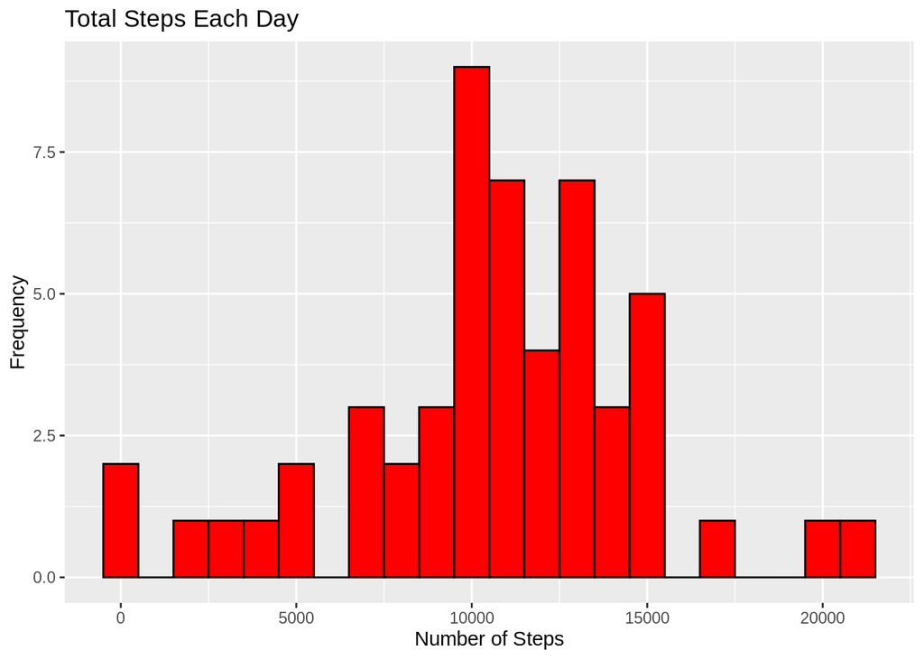

```r
steps_by_day <- aggregate(steps ~ date, data = activity , sum)
#Adding column names to the created data frame
colnames(steps_by_day) <- c("date", "steps")
# date is a factor, so i sum every step by days
ggplot(steps_by_day, aes(x = steps)) +
    geom_histogram(fill = "red", binwidth = 1000, color="black") +
    labs(title = "Total Steps Each Day", x = "Number of Steps", y = "Frequency")
```

# Mean and median number of steps taken each day

```r
mean <- mean(steps_by_day$steps)
median <- median(steps_by_day$steps)
mean
```

```
## [1] 10766.19
```

```r
median
```

```
## [1] 10765
```

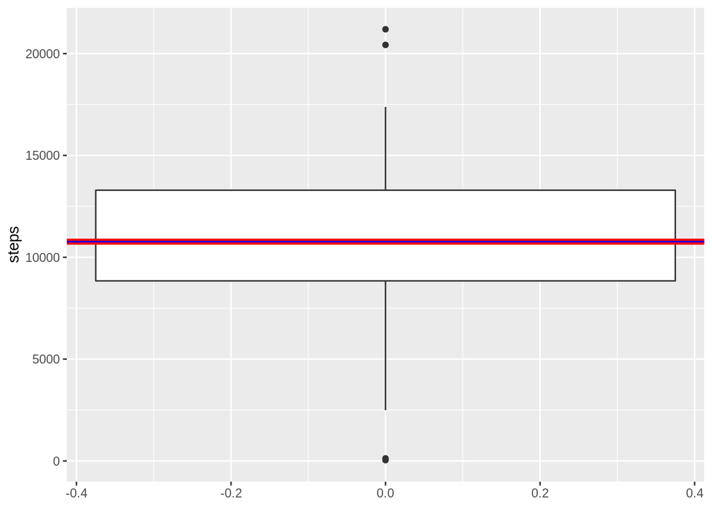

```r
ggplot(steps_by_day, aes(y = steps)) +
    geom_boxplot() +
    geom_hline(yintercept = mean, color="red", size=2) +
    geom_hline(yintercept = median, color="blue")
```

# Time series plot of the average number of steps taken

```r
steps <- aggregate(activity$steps, by=list(interval=activity$interval), FUN=mean)
colnames(steps) <- c("interval", "average_steps")
max_steps <- max(steps$average_steps)
max_steps
```

```
## [1] 206.1698
```

```r
intervale_max_steps <- steps[which.max(steps$average_steps),]$interval
intervale_max_steps
```

```
## [1] 835
```

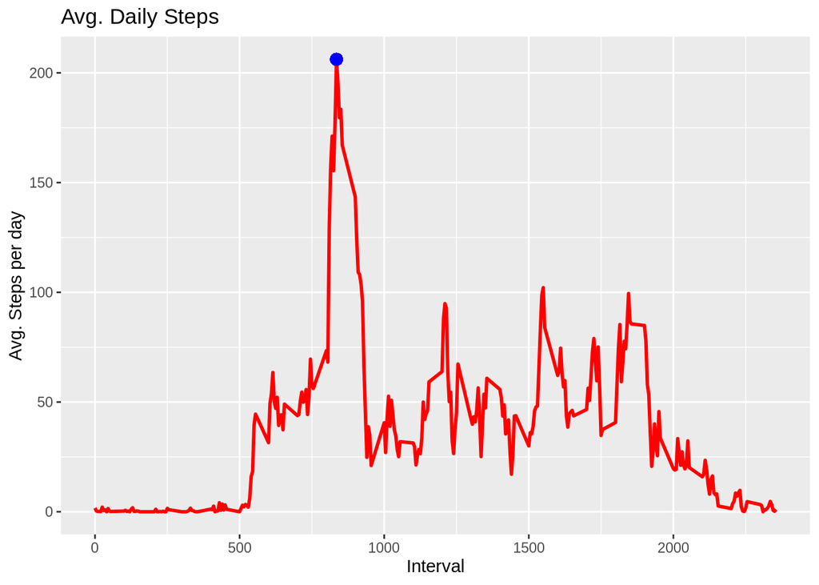

```r
ggplot(steps, aes(x = interval , y = average_steps)) +
        geom_line(color="red", size=1) +
        labs(title = "Avg. Daily Steps", x = "Interval", y = "Avg. Steps per day") +
        geom_point(x = intervale_max_steps , y = max_steps , colour="blue", size = 3)
```